# Creating images with R

with a little bit of magick

Joanna Kim

2023-03-12

## My Meme

[figure not shown]

## About my meme

I created this meme with `R` code in posit Cloud (r studio) using the `Magick` package. I was inspired to create this meme when I encountered a lockdown online class meme with all different types of students in an online call with a teacher. For my meme creation, I used the format of two stacked images along with text next to the images. Three main elements to why I decided to make my meme with cats and about online classes:

1. My love for cats (although I’m *allergic* to cat fur) I ADORE them
2. Due to the pandemic I started off my first year of university with online tutorials/labs and prerecorded lectures, which reminded me how different it was last year
3. Starting to miss not having to wake up early to bus to the *University of Auckland* which now makes me feel like I’m starting uni for the first time going to in-person classes every day

```r
library(magick)

# online class meme

# square one
teachers_text <- image_blank(width = 500,
                            height = 317.5,
                            color = "#ffffff") %>%
  image_annotate(text = "The teacher:",
                 color = "#666666",
                 size = 50,
                 font = "Impact",
                 gravity = "center")

# square two
enthusiastic_teacher_text <- image_read("https://i.pinimg.com/474x/bf/f5/d0/bff5d074d399bdfec6071e9168398406.jpg") %>%
  image_scale(500) %>%
  image_annotate(text = "Good Morning Class!",
                 color = "#ffff33",
                 size = 30,
                 font = "Impact",
                 gravity = "south")


# square three
students_text <- image_blank(width = 500,
                       height = 375.2,
                       color = "#ffffff") %>%
  image_annotate(text = "Every student with \n their camera \n and mic off:",
                 color = "#666666",
                 size = 50,
                 font = "Impact",
                 gravity = "center")


# square four
speechless_text <- image_read("https://static.boredpanda.com/blog/wp-content/uploads/2021/07/tucked-in-kitties-subreddit-60f941152cfa3__700.jpg") %>%
  image_scale(500) %>%
  image_annotate(text = "...",
                 color = "#ffff33",
                 size = 30,
                 font = "Impact",
                 gravity = "south")

# combining the top row
teacher_vector <- c(teachers_text, enthusiastic_teacher_text)
top_row <- image_append(teacher_vector)

# combining the bottom row
all_students_vector <- c(students_text, speechless_text)
bottom_row <- image_append(all_students_vector)

#final meme combined
online_class_meme <- c(top_row, bottom_row) %>%
  image_append(stack = TRUE) %>%
  image_scale(800)

image_write(online_class_meme, "online_class_meme.png")
```

## My animated GIF

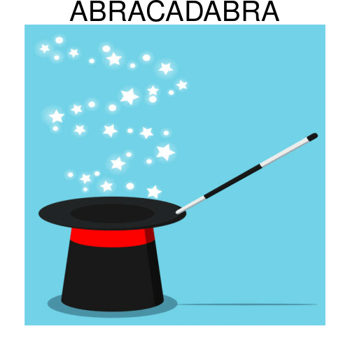

## About my animation

I created this animation with `R` code in posit Cloud (r studio) using the `Magick` package. I was trying to get some inspiration for my animation that could be simple, yet still appealing. For my animated GIF, I used four frames using the URL link for four different images and added a border, and included some text around the border. When I asked my peers for some broad ideas I could use to find the animation I wanted to create, I got motive by these suggestions:

- An animal in the GIF
- A box with a surprise coming out
- Easter themed since Easter is coming up

```r
library(magick)

first_image <- image_read("https://media.istockphoto.com/id/1176390869/vector/vector-flat-design-cartoon-style-illustration-magic-black-hat-with-magic-wand-and-magical.jpg?s=612x612&w=0&k=20&c=CLIZyTFH-hBFrt-D_rp-Cq4nGTUHRXCZJjHpUuX_e7g=") %>%
  image_border("white", "50x50") %>%
  image_scale(500)


second_image <- image_read("https://media.istockphoto.com/id/1167235346/vector/icon-of-magic-black-hat-with-white-rabbit-bunny-ears.jpg?s=612x612&w=0&k=20&c=tSpJ_OIefmJdoTaJyR7a7basiQiqrdRXivB8gz9-0T8=") %>%
  image_border("red", "50x50") %>%
  image_scale(500)

third_image <- image_read("https://media.istockphoto.com/id/1167235374/vector/magic-black-hat-with-sweet-white-rabbit-inside.jpg?s=612x612&w=0&k=20&c=RzGlnObZDri17bOfREkfQNhfjB9jX_cZ_beSwxH6uGY=") %>%
  image_border("white", "50x50") %>%
  image_scale(500)

fourth_image <- image_read("https://media.istockphoto.com/id/1167235336/vector/isolated-cute-and-sweet-white-bunny-rabbit-in-sitting-pose-with-red-heart.jpg?s=612x612&w=0&k=20&c=PiLrBCFpa3s96-SybQH6dqTwjMw8qOgZskrBnlFL330=") %>%
  image_border("red", "50x50") %>%
  image_scale(500)

# creating each frame, with the text describing each frame
frame1 <- first_image %>%
  image_annotate(text = "ABRACADABRA", size = 40, gravity = "north", font = "Georgia") %>%
  image_scale(500) %>%
  image_extent("500x500")

frame2 <- second_image %>%
  image_annotate(text = "???", size = 40, gravity = "northwest", font = "Georgia") %>%
  image_scale(500) %>%
  image_extent("500x500")

frame3 <- third_image %>%
  image_annotate(text = "TAAADAA!!!", size = 40, gravity = "northeast", font = "Georgia") %>%
  image_scale(500) %>%
  image_extent("500x500")

frame4 <- fourth_image %>%
  image_scale(500) %>%
  image_extent("500x500")

# putting the frames in order using a vector
frames <- c(frame1, frame2, frame3, frame4)

# creating an animation
magic_animation <- image_animate(frames, fps = 1)

image_write(magic_animation, "magic_animation.gif")
```